# Bayaraa_TidyBio_Fall2023_FinalProject

Odmaa Bayaraa

2023-11-05

## R Markdown

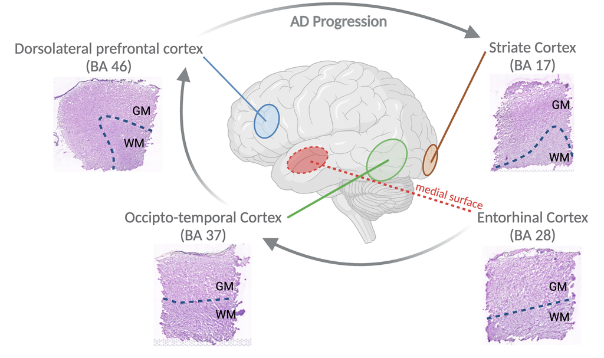

The broader project aims to compare isoform expression accross 4 different brain regions of differing vulnerability to Alzheimer’s Disease (AD) pathology. Post-mortem fresh-frozen human brain tissue was used to generate spatial transcriptomics libraries that were Oxford Nanopore long-read sequenced (ONT). This isoform expression was QC’ed and quantified using the SiceLore pipeline.

This project aims to plot the isoforms of a specific gene of interest and visually quantify/compare the percent expression across the different brain regions. This specific run focuses on the isoforms of S100B, a member of the S100 protein family, which is glial-specific and implicated in wide range of neurodegenerative diseases.

```r
#Installing and loading ggtranscript
#install.packages('ggtranscript') #dependencies might have compatibility issues with newer versions of R
#Use BiocManager to seperately install dependencies like GenomeInfoDb,GenomicRanges
library(ggtranscript)

#Loading other libraries
library(magrittr)
library(dplyr)
library(ggplot2)
library(rtracklayer)
library(ggpubr)
library(patchwork)
library(tidyr)

#Changing working directory
getwd()
```

```
## [1] "/Users/odmaabayaraa/Desktop/tidybiology"
```

```r
setwd("/Users/odmaabayaraa/Desktop/tidybiology")

#Setting parameters
gene_of_interest<-'S100B' #Defining gene of interest
box_color<-'#F7B500' #Setting box color of isoform diagrams
brain_region_color_palette<-c("#e63f40","#57b154","#4e8dbf","#a45223") #Setting colors of regions in order ENT,OCCP,MF,TEMP
```

## 1. Importing Genome Annotation from GTF

In this section we are importing the GENCODE human genome annotation from a gene transfer format (GTF) file.

```r
#Importing Gencode Genome annotation GTF data
#Loading in gtf.gz annotation file
gtf <- rtracklayer::import("gencode.v44.annotation.gtf.gz")
class(gtf)
```

```
## [1] "GRanges"
## attr(,"package")
## [1] "GenomicRanges"
```

```r
#Converting to data frame or tibble to make compatible for input
gtf <- gtf %>% dplyr::as_tibble()
class(gtf)
```

```
## [1] "tbl_df"     "tbl"        "data.frame"
```

## 2. Filtering Annotation for Gene of Interest

Here, we are filtering the GENCODE annotation that has 3424189 annotated regions (rows) for ones that match our gene of interest. We are also removing unnecessary annotation information (cols).

```r
#Filtering gtf which has 3424189 annotations for the gene of interest, here "S100B"
gene_annotation_from_gtf <- gtf %>%
  dplyr::filter(
    !is.na(gene_name),
    gene_name == gene_of_interest
  )

#filtering annotation columns that are needed downstream
gene_annotation_from_gtf <- gene_annotation_from_gtf %>%
  dplyr::select(
    seqnames,
    start,
    end,
    strand,
    type,
    gene_name,
    transcript_name,
    transcript_type,
    transcript_id
  )

gene_annotation_from_gtf %>% head()
```

```
## # A tibble: 6 × 9
##   seqnames   start    end strand type  gene_name transcript_name transcript_type
##   <fct>      <int>  <int> <fct>  <fct> <chr>     <chr>           <chr>
## 1 chr21     4.66e7 4.66e7 -      gene  S100B     <NA>            <NA>
## 2 chr21     4.66e7 4.66e7 -      tran… S100B     S100B-201       protein_coding
## 3 chr21     4.66e7 4.66e7 -      exon  S100B     S100B-201       protein_coding
## 4 chr21     4.66e7 4.66e7 -      exon  S100B     S100B-201       protein_coding
## 5 chr21     4.66e7 4.66e7 -      CDS   S100B     S100B-201       protein_coding
## 6 chr21     4.66e7 4.66e7 -      star… S100B     S100B-201       protein_coding
## # ℹ 1 more variable: transcript_id <chr>
```

## 3. Initial Plot of Introns and Exons

In this block, we will be filtering the exonic regions and creating an initial transcript plot to visualize the isoforms of the gene we selected.

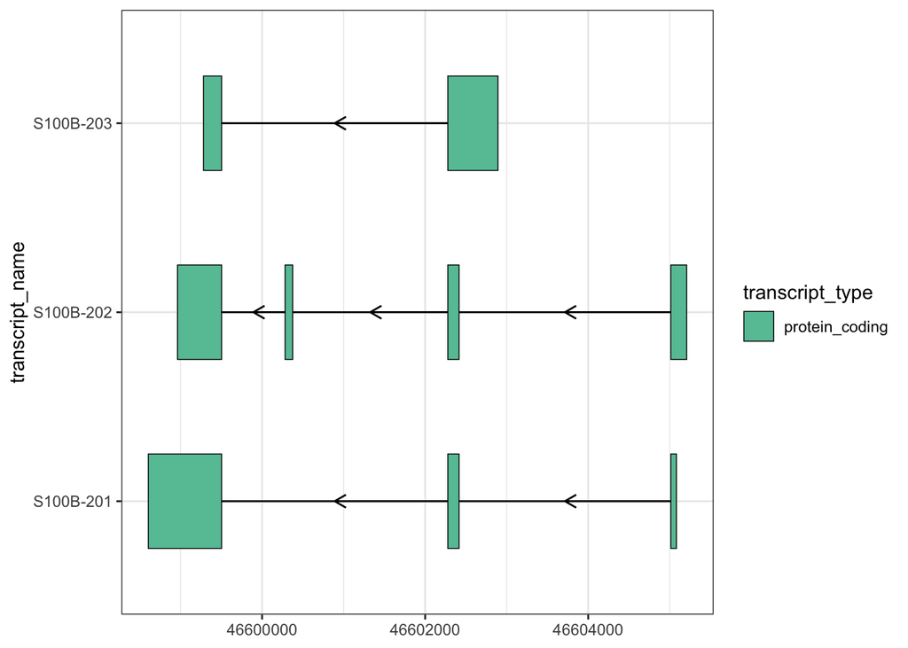

```r
#Filtering all exonic regions
gene_exons <- gene_annotation_from_gtf %>% dplyr::filter(type == "exon")

#Plotting exonic regions
gene_exons %>%
  ggplot(aes(
    xstart = start,
    xend = end,
    y = transcript_name
  )) +
  geom_range(
    aes(fill = transcript_type)
  ) +
  scale_fill_brewer(palette = "Set2")+
  geom_intron(
    data = to_intron(gene_exons, "transcript_name"),
    aes(strand = strand)
  )+
  theme_bw()
```

## 4. Differentiating UTRs from the coding sequence

Since these isoforms consist of both protein coding and untranslated regions (UTRs), we will be differentiating them in our transcript plots by adjusting their height.

```r
#Filtering gene exons for protein_coding regions
gene_exons_prot_cod <- gene_exons %>%
  dplyr::filter(transcript_type == "protein_coding")

#Filtering the gene annotation gtf for coding regions
gene_cds <- gene_annotation_from_gtf %>% dplyr::filter(type == "CDS")

#Ploting the transcripts
gene_transcript_plots<-gene_exons_prot_cod %>%
  ggplot(aes(
    xstart = start,
    xend = end,
    y = transcript_id
  )) +
  geom_range(
    fill = box_color,
    height = 0.25
  ) +
  geom_range(
    data = gene_cds,
    fill= box_color
  ) +
  geom_intron(
    data = to_intron(gene_exons_prot_cod, "transcript_name"),
    aes(strand = strand),
    arrow.min.intron.length = 500,
  ) +
  xlab(paste0("Chr",extract_numeric(gene_exons_prot_cod$seqnames[1])," Position"))+
  ylab("Transcript ID")+
  theme_bw()
```

```
## extract_numeric() is deprecated: please use readr::parse_number() instead
```

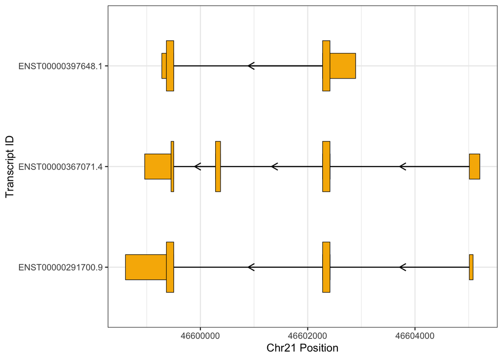

```r
gene_transcript_plots
```

## 5. Importing nbUMI count table and plotting barplots

This section takes in our count data (nbUMI) tables generated for each of the brain regions and filters them for the gene of interest.

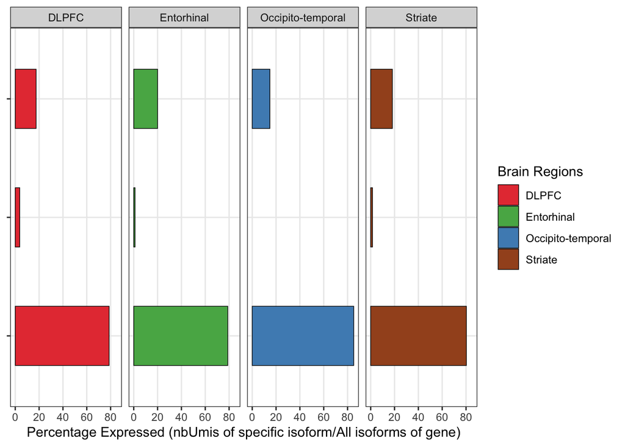

```r
#Creating an empty data frame
gene_isoform_exp<-data.frame(matrix(nrow=0,ncol=7))
colnames(gene_isoform_exp)<-c("geneId","transcriptId","nbExons","nbUmis","region")

#Looping through the files for each of the regions, filtering out undefined transcripts and adding them to the gene_isoform_exp table
for(i in c('ENT','OCCP','MF',"TEMP")){
  region_file<-read.csv(paste0(i,"_isometrics.txt"),sep='\t')
  region_file$region<-rep(i,nrow(region_file))
  region_file_gene_filtered<-region_file%>%
    filter(geneId==gene_of_interest & transcriptId!="undef")
  gene_isoform_exp<-rbind(gene_isoform_exp,region_file_gene_filtered)
}

#Calculating the percentage of each isoform's expression for each region
gene_isoform_exp<-gene_isoform_exp %>%
  group_by(region) %>%
    mutate(percent_exp=(nbUmis/sum(nbUmis))*100)

#Creating a dictionary to create new labels for each region
region_names_dict<-c("ENT"='Entorhinal',"OCCP"="Occipito-temporal","MF"="DLPFC","TEMP"="Striate")
gene_isoform_exp<-gene_isoform_exp %>%
  mutate(region_label=factor(region_names_dict[region],levels=c("Entorhinal","Occipito-temporal","DLPFC","Striate")))

#Transcripts might be missing from count data (not detected) which are added to adjust for the number of transcript groups
missing_levels<- data.frame(geneId=gene_of_interest,transcriptId = levels(as.factor(gene_exons_prot_cod$transcript_id)), percent_exp = NA, region="ENT",region_label="Entorhinal")

#Adding these 'missing' transcripts to the gene_isoform_exp table
gene_isoform_exp<-rbind(gene_isoform_exp,missing_levels)

#Making sure that the level orders match between the transcript plots and count data plots
gene_isoform_exp$transcriptId<-factor(gene_isoform_exp$transcriptId,levels=levels(as.factor(gene_exons_prot_cod$transcript_id)))

#Removing rows where the transcriptId is missing
gene_isoform_exp<-gene_isoform_exp %>%
  filter(!is.na(transcriptId))

#Plotting each of the brain regions and the percentage expression of each isoform
region_bp<-ggplot(data=gene_isoform_exp,aes(x=transcriptId,y=percent_exp,fill=region_label))+
  geom_bar(stat = "identity", width = 0.5,colour='black',linewidth=0.25) +
  coord_flip() + facet_wrap(~region_label, ncol=4)+
  scale_fill_manual(values=brain_region_color_palette)+
  ylab("Percentage Expressed (nbUmis of specific isoform/All isoforms of gene)")+
  guides(fill=guide_legend(title="Brain Regions"))+
  theme_bw()+
  theme(axis.text.y = element_blank(), axis.title.y=element_blank(),panel.grid.minor = element_blank())
region_bp
```

## 6. Combining plots

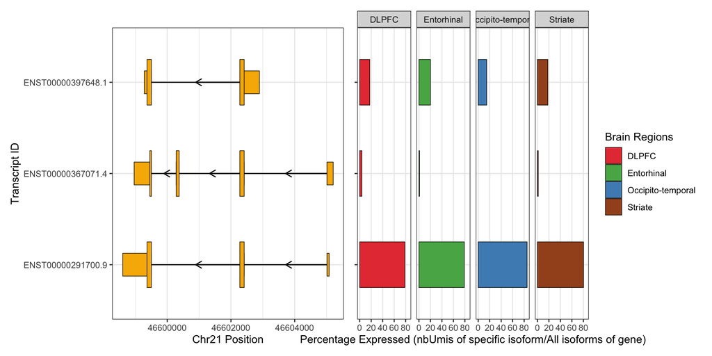

```r
#Using patchwork to plot/align graphs horizontally
gene_transcript_plots+region_bp
```

## Conclusions

From this final plot, we can see that across all the four brain regions there is higher expression of ENST00000291700.9 and some expression of ENST00000397648.1. This may suggest that S100B’s isoform expression is highly conserved even during AD and this pathway of glial function is not perturbed by disease state.

## Prioritized follow-up studies

Further work can be carried out to understand why this specific transcript of S100B expression is highly conserved, perhaps through generating primary protein sequences from these transcripts and analyzing their folding through AlphaFold. Furthermore, the low nbUMI from the long-read count data demonstrates a need for a higher throughput long-read sequencing in future studies.

## Acknowledgements

I would like to acknowledge the ggtranscript team and @dzhang32 for this great vignette (https://github.com/dzhang32/ggtranscript), Heberle et al for the plot inspiration (https://pubmed.ncbi.nlm.nih.gov/37609156/) and the Tidy Biology class instructors and fellow students.